# Rqc 1.40.0 - Quality Control Report

## File Information

This table describes input files. `reads` column can be total number of reads (`sample=FALSE`) or sample size.

| filename | pair | format | group | reads | total.reads | path |
| --- | --- | --- | --- | --- | --- | --- |
| ERR127302_1_subset.fastq.gz | 1 | FASTQ | None | 20000 | 20000 | /Users/abatta00/Library/R/arm64/4.4/library/ShortRead/extdata/E-MTAB-1147 |
| ERR127302_2_subset.fastq.gz | 2 | FASTQ | None | 20000 | 20000 | /Users/abatta00/Library/R/arm64/4.4/library/ShortRead/extdata/E-MTAB-1147 |

## Per Read Mean Quality Distribution of Files

This plot describe an overview of per read mean quality distribution of all files

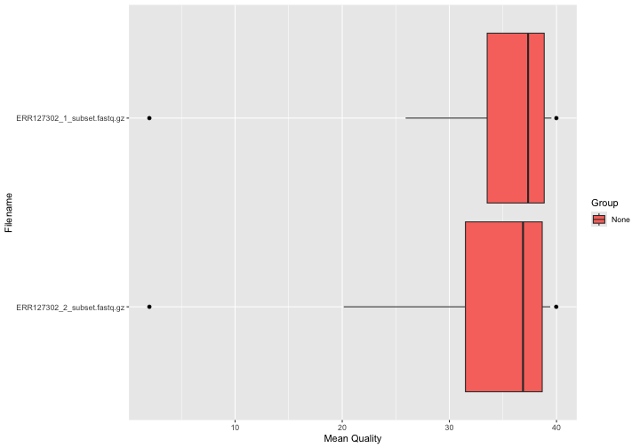

## Average Quality

This plot describes the average quality pattern by showing on the X-axis quality thresholds and on the Y-axis the percentage of reads that exceed that quality level.

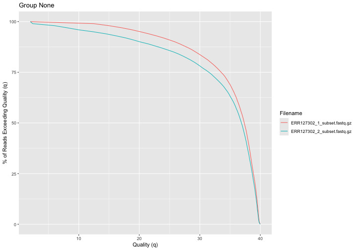

## Cycle-specific Average Quality

This plot describes the average quality scores for each cycle of sequencing.

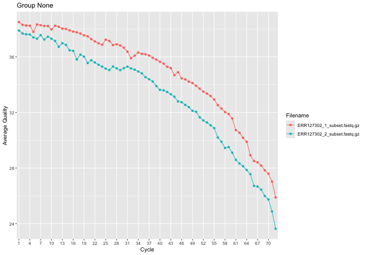

## PCA Biplot (cycle-specific read average quality)

Biplot from Principal Component Analysis (PCA) of cycle-specific read average quality.

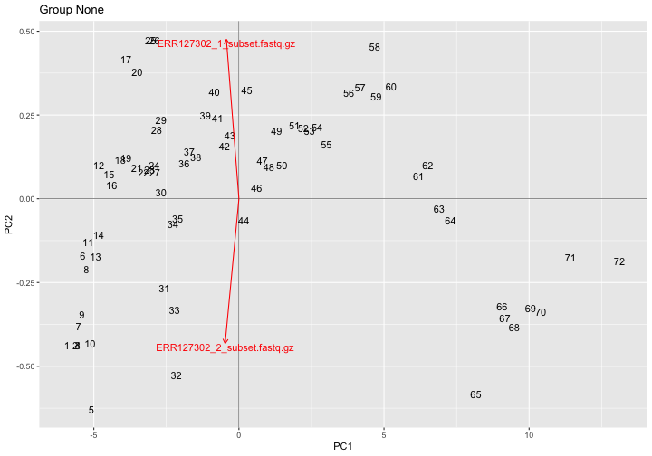

## Read Frequency

This plot shows the proportion of reads that appeared many times.

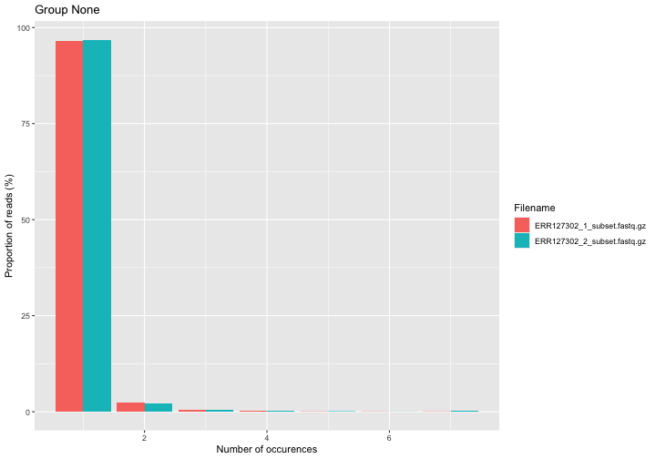

## Read Length Distribution

Barplot that presents the distribuition of the lengths of the reads available in the FASTQ file.

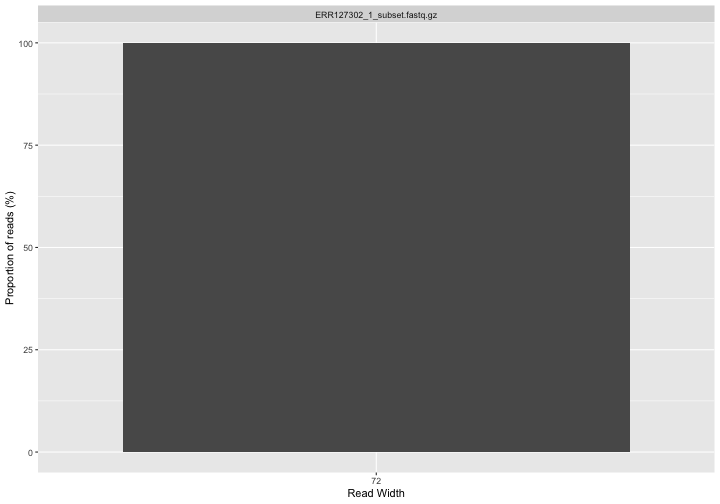

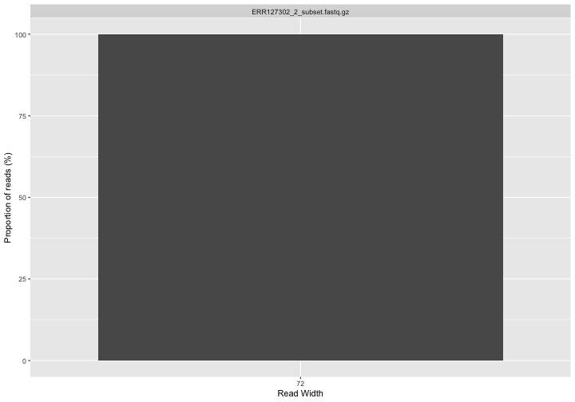

## Cycle-specific GC Content

Line plot showing the average GC content for every cycle of sequencing.

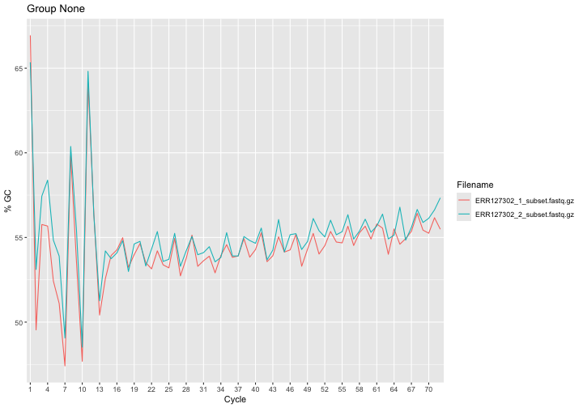

## Cycle-specific Quality Distribution

Bar plot showing the proportion of quality calls per cycle. Colors are presented in a gradient Red-Blue, where red identifies calls of lower quality. This visualization is preferred as it is cleaner than the boxplots described below.

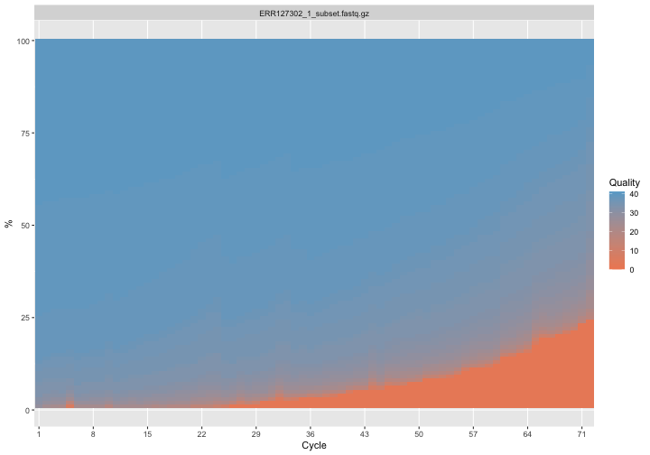

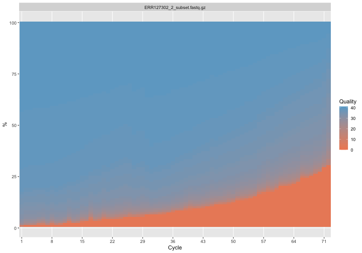

## Cycle-specific Quality Distribution - Boxplot

Boxplots describing empirical patterns of quality distribution on each cycle of sequencing.

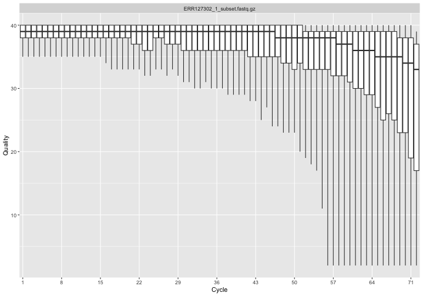

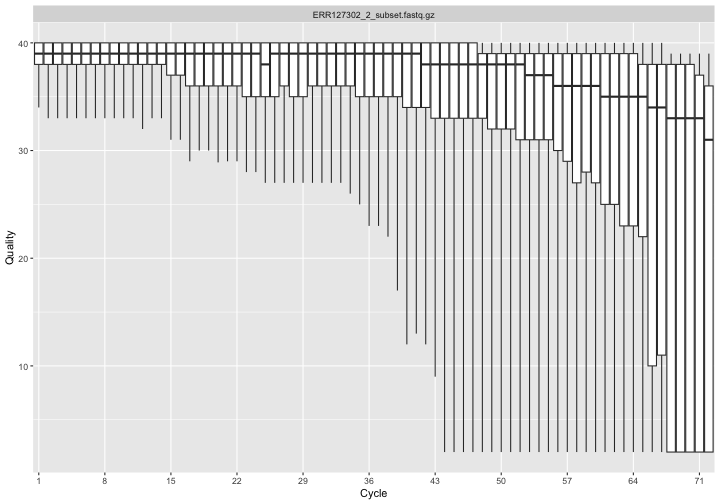

## Cycle-specific Base Call Proportion

This stacked bar plot describes the proportion of each nucleotide called for every cycle of sequencing.

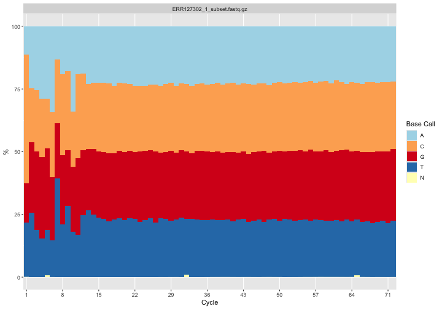

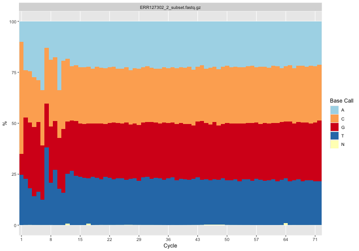

The line plot shown below contains the same information as the plot above. However, some may find this easier to read when comparing the calling rates for each of the nucleotides.

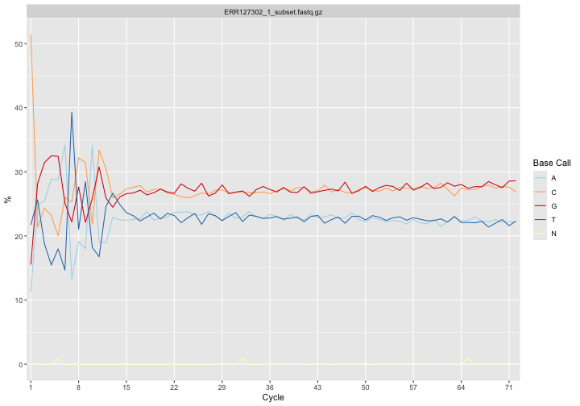

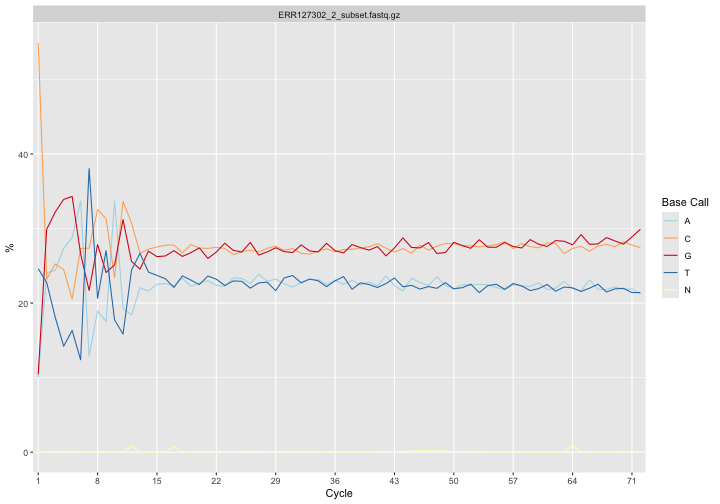